# HSAM: Analisi Go-NoGo

Author

Lorenzo Atzeni

### Pre-processing, data cleaning

Ho applicato una procedura simile a quella del dataframe del matching task, selezionando solo trial eseguiti correttamente (accuratezza=1) della condizione go. Inoltre ho escluso tempi di reazione estremi, definiti come valori oltre ±3 deviazioni standard dalla media per ciascun partecipante e condizione.

trial per CNTRL (head) e HSAM (tail)

|  | ID_CNTRL | other-first | self-first | ID_HSAM | other-first | self-first |
| --- | --- | --- | --- | --- | --- | --- |
| CNTRL01 | CNTRL01 | 100 | 100 | HM11 | 100 | 100 |
| CNTRL02 | CNTRL02 | 100 | 100 | HM12 | 100 | 100 |
| CNTRL04 | CNTRL04 | 100 | 100 | HM13 | 100 | 100 |
| CNTRL05 | CNTRL05 | 100 | 100 | HM14 | 100 | 100 |
| CNTRL07 | CNTRL07 | 100 | 100 | HM15 | 100 | 100 |
| CNTRL08 | CNTRL08 | 100 | 100 | HM16 | 100 | 100 |

Selezioniamo solo trial corretti:

trial per CNTRL (head) e HSAM (tail)

|  | ID_CNTRL | other-first | self-first | ID_HSAM | other-first | self-first |
| --- | --- | --- | --- | --- | --- | --- |
| CNTRL01 | CNTRL01 | 50 | 49 | HM11 | 50 | 50 |
| CNTRL02 | CNTRL02 | 50 | 50 | HM12 | 50 | 49 |
| CNTRL04 | CNTRL04 | 50 | 50 | HM13 | 49 | 50 |
| CNTRL05 | CNTRL05 | 49 | 50 | HM14 | 45 | 48 |
| CNTRL07 | CNTRL07 | 46 | 48 | HM15 | 50 | 49 |
| CNTRL08 | CNTRL08 | 48 | 50 | HM16 | 45 | 43 |

CNTRL_13 deve essere escluso perchè ha sbagliato tutti i trial eccetto 1.

```
          self-first
  CNTRL13          1
```

Eliminiamo adesso RT sotto e sopra 3 sd media ciascun partecipante e condizione:

```
Soggetto CNTRL01 - Blocco other-first : eliminati 1 outlier
Soggetto CNTRL02 - Blocco self-first : eliminati 1 outlier
Soggetto CNTRL04 - Blocco self-first : eliminati 1 outlier
Soggetto CNTRL05 - Blocco self-first : eliminati 1 outlier
Soggetto CNTRL07 - Blocco self-first : eliminati 1 outlier
Soggetto CNTRL07 - Blocco other-first : eliminati 1 outlier
Soggetto CNTRL08 - Blocco self-first : eliminati 1 outlier
Soggetto CNTRL08 - Blocco other-first : eliminati 1 outlier
Soggetto CNTRL10 - Blocco self-first : eliminati 1 outlier
Soggetto CNTRL10 - Blocco other-first : eliminati 1 outlier
```

[output not shown]

Mediamente è stata eliminata una osservazione per soggetto.

| Condizione | Media_RT | SD_RT |
| --- | --- | --- |
| SCONOSCIUTO | 0.483 | 0.114 |
| TU | 0.472 | 0.109 |

Visualizziamo gli RT delle due condizioni

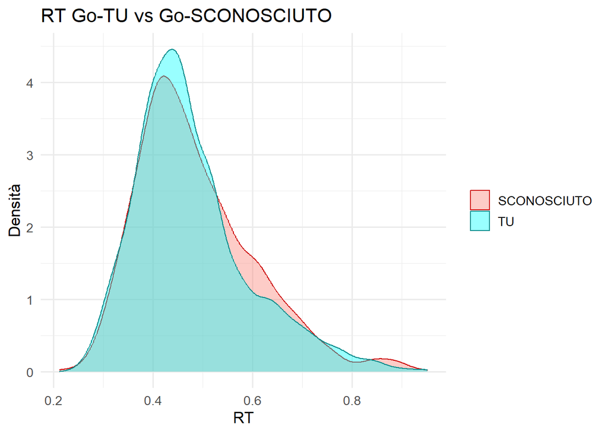

Adesso fittiamo il modello:

```r
form<-bf(rt~ordine*group + (1+ordine|id_subj),
         family = Gamma(link = "log"))

myPRIORS <- c(
  set_prior("student_t(3, 0, 1)", class = "Intercept"),

  set_prior( paste0("student_t(3, 0, .08)"), class = "b",
             coef = "ordineTU"),
  set_prior( paste0("student_t(3, 0, .08)"), class = "b",
             coef = "groupHSAM"),
  #set_prior( paste0("student_t(3, 0, .0055)"), class = "b",
  set_prior( paste0("student_t(3, 0, .08)"), class = "b",
             coef = "ordineTU:groupHSAM"),
  set_prior( paste0("student_t(3, 0, 1)"), class = "sd" ),
  set_prior(paste0("gamma(17, 34)"), class = "shape"))


fit_bayes<- brm(
  formula = form,
  data = df_go_pulito,
  prior = myPRIORS,
  chains = 4,
  cores = parallel::detectCores(),
  iter = 4000,
  warmup = 1000,
  seed = 1,
  control = list(adapt_delta = 0.99)
)
```

```
 Family: gamma
  Links: mu = log; shape = identity
Formula: rt ~ ordine * group + (1 + ordine | id_subj)
   Data: df_go_pulito (Number of observations: 2446)
  Draws: 4 chains, each with iter = 4000; warmup = 1000; thin = 1;
         total post-warmup draws = 12000

Multilevel Hyperparameters:
~id_subj (Number of levels: 27)
                        Estimate Est.Error l-90% CI u-90% CI Rhat Bulk_ESS
sd(Intercept)               0.16      0.03     0.12     0.20 1.00     4137
sd(ordineTU)                0.06      0.02     0.04     0.09 1.00     5049
cor(Intercept,ordineTU)    -0.19      0.24    -0.56     0.23 1.00     8827
                        Tail_ESS
sd(Intercept)               5272
sd(ordineTU)                5929
cor(Intercept,ordineTU)     7955

Regression Coefficients:
                   Estimate Est.Error l-90% CI u-90% CI Rhat Bulk_ESS Tail_ESS
Intercept             -0.74      0.04    -0.81    -0.67 1.00     3969     5708
ordineTU              -0.04      0.02    -0.07    -0.01 1.00     9247     8168
groupHSAM              0.01      0.05    -0.07     0.09 1.00     4903     5779
ordineTU:groupHSAM     0.03      0.03    -0.01     0.08 1.00     9844     8799

Further Distributional Parameters:
      Estimate Est.Error l-90% CI u-90% CI Rhat Bulk_ESS Tail_ESS
shape    17.75      0.51    16.92    18.60 1.00    18124     8474

Draws were sampled using sampling(NUTS). For each parameter, Bulk_ESS
and Tail_ESS are effective sample size measures, and Rhat is the potential
scale reduction factor on split chains (at convergence, Rhat = 1).
```

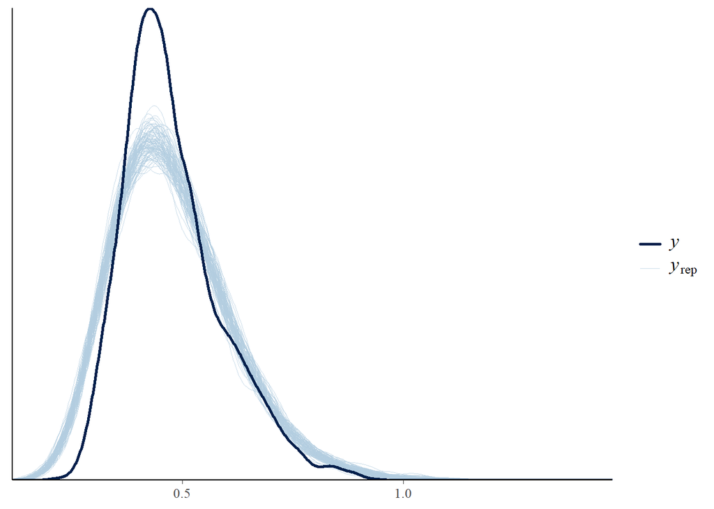

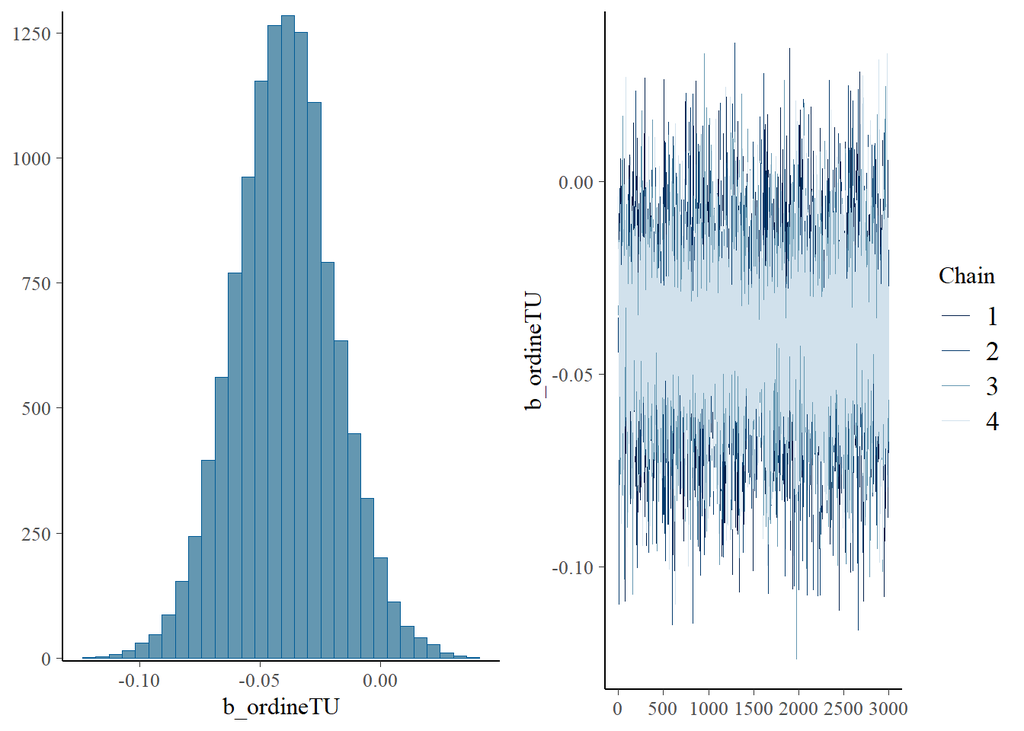

La probabilità che sia negativo è di:

```
[1] 0.971
```

Mentre la prob. a posteriori che sia positivo è di:

```
[1] 0.029
```

Sulla base di queste informazioni possiamo dichiarare che date le nostre posterior, è estremamente più probabile che, i partecipanti rispondono più rapidamente nella condizione TU rispetto a quella SCONOSCIUTO.

Analogamente il parametro B3 di interazione, mostra una stima positiva di 0.03, ma l’intervallo di credibilità comprende lo zero (da −0.01 a 0.08). Andando a vedere la posterior (grafico sotto) si può poi calcolare la probabilità a posteriori che il parametro sia dentro l’intervallo nullo di +-10ms, e la probabilità che sia positivo o negativo.

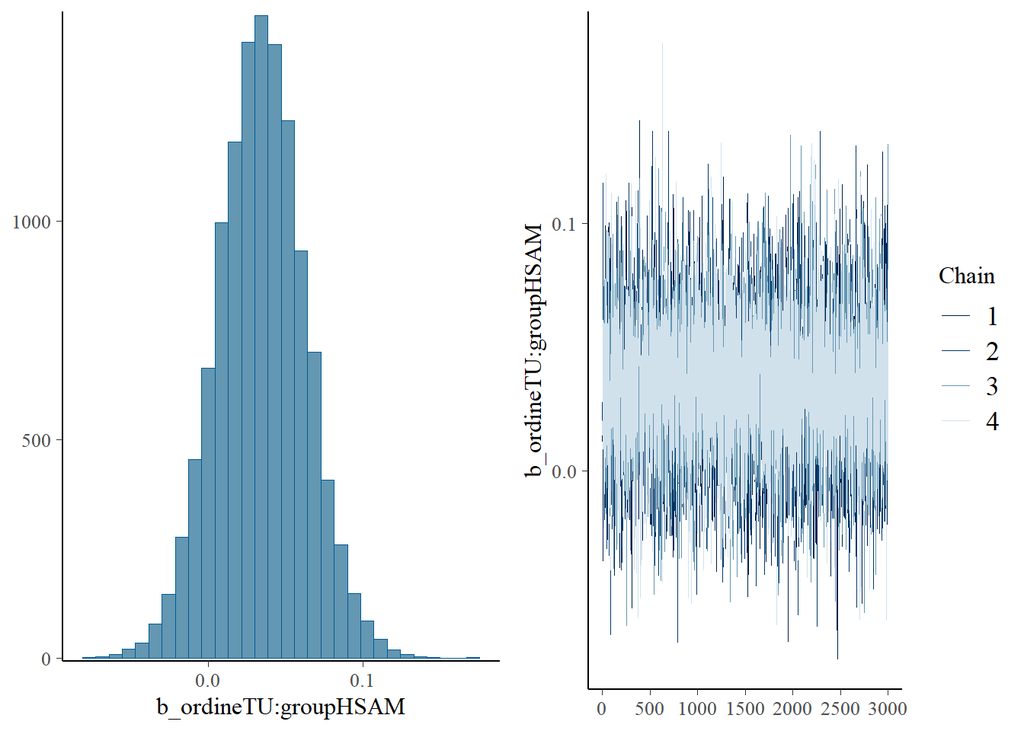

La probabilità che B3 sia negativo è di:

```
[1] 0.10875
```

Mentre la prob. a posteriori che B3 sia positivo è di:

```
[1] 0.89125
```

L’intervallo nullo (NI) di B3 di+-10ms è compreso tra [-0.020 ; 0.020] e la prob a posteriori che il parametro caschi in tale intervallo è di:

```
[1] 0.27875
```

Per B3 avevamo scelto come prior una student_t(3, 0, .08). La prob. a priori che B3 si trovasse nel NI era di

```
[1] 0.1812708
```

Quindi possiamo concludere che aggiornando le prior con i dati raccolti, la prob. che B3 cada nel NI è aumentata di

```
[1] 0.09747922
```

I dati hanno *aumentato* l’evidenza a favore dell’effetto nullo rispetto alla prior.

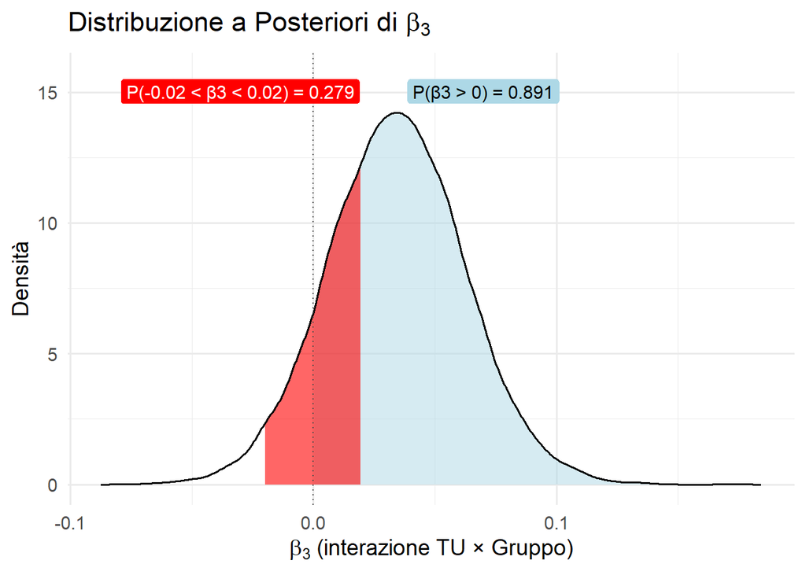

Ho fittato anche il modello frequentista per vedere eventuale convergenze/divergenze:

```
 Family: Gamma  ( log )
Formula:          rt ~ ordine * group + (1 + ordine | id_subj)
Data: df_go_pulito

      AIC       BIC    logLik -2*log(L)  df.resid
  -5262.7   -5216.2    2639.3   -5278.7      2438

Random effects:

Conditional model:
 Groups  Name        Variance Std.Dev. Corr
 id_subj (Intercept) 0.021341 0.14608
         ordineTU    0.004457 0.06676  -0.25
Number of obs: 2446, groups:  id_subj, 27

Dispersion estimate for Gamma family (sigma^2): 0.0291

Conditional model:
                   Estimate Std. Error z value Pr(>|z|)
(Intercept)        -0.73956    0.04108 -18.001   <2e-16 ***
ordineTU           -0.04634    0.02085  -2.222   0.0263 *
groupHSAM           0.01122    0.05717   0.196   0.8444
ordineTU:groupHSAM  0.04476    0.02938   1.523   0.1277
---
Signif. codes:  0 '***' 0.001 '**' 0.01 '*' 0.05 '.' 0.1 ' ' 1
```